# GSE183973 DESeq2

Mikias HW

2024-03-15

*Work in progress* (https://github.com/MikiasHWT/Bulk-RNA-Seq)

Purpose : Comparison of RNA expression of three innate immune cell populations across three patient groups.

Load libraries

```r
library(prettydoc)
# library(GEOquery) # import datasets from GEO (unused)
library(DESeq2) # Diverential gene expression analysis
library(vsn) # Transformation
library(apeglm) # log fold shrinking (adaptive t prior shrinkage estimator)
library(ashr) # log fold shrinking (adaptive shrinkage estimator)
library(pheatmap) # heatmaps
library(RColorBrewer) # Color themes
library(EnhancedVolcano) # Pleasing volcano plots
library(gridExtra) # GGplot extention
library(DT) # nice data tables
library(SparseArray)
library(ggvenn)
library(qvalue)

library(org.Mm.eg.db) # Mouse database
library(org.Hs.eg.db) # Human database
library(DOSE)
library(pathview)
library(clusterProfiler) # over representation/gene enrichment
library(AnnotationHub)
library(ensembldb)
library(enrichplot)
library(biomaRt)
library(ReactomePA)
library(ggupset)
library(cowplot)
library(europepmc)
library(ggstance)
# library(GO.db) # Gene ontology
# library(GOstats) # Gene ontology
library(tidyverse) # data wrangling & visualization
library(conflicted)
```

Conflicted functions

```r
# Set function preferences
conflicts_prefer(dplyr::select)

conflicts_prefer(dplyr::filter)

conflicts_prefer(dplyr::slice)

conflicts_prefer(SparseArray::rowSds)
```

Define MA Plotting function **MA plot** visualizes relationships between log ratio & mean values of two variables: • “M” = minus in the log scale. Log ratios on (y) axis. • “A” = average in the log scale. The mean values on (x) axis.

```r
# MA Plots
# Arranged into 2 rows
# Color & translucency by DEG
# Plot titles fed in as arguments
# Mean counts (x-axis) Log10 transformed

plotMA_arrange_iterative <- function(res_list) {
  plots <- list()

  for (i in seq_along(res_list)) {
    res <- res_list[[i]]
    res_name <- names(res_list)[i] # Get the name of the res object
    p <- plotMA(res, returnData = TRUE) # DESeq2's PlotMA function
    p_plot <- ggplot(p, aes(x = mean, y = lfc, color = isDE)) +
      geom_point(aes(alpha = ifelse(isDE == "TRUE", 1, 0.1)), show.legend = FALSE) + # Reduce non DEG genes transperancy
      scale_x_continuous(trans = "log10") + # Scale mean counts
      ylim(-2, 2) +
      labs(title = res_name) # Use the name in the plot title

    plots[[i]] <- p_plot
  }

  do.call(grid.arrange, c(plots, nrow = 2))
}
```

# Preparation

*Note:* Using GEOquery will require some troubleshooting as the GSE submission for this dataset lacked feature information. Instead the CSV files for gene counts and metadata can be download directly from [GEO](https://www.ncbi.nlm.nih.gov/geo/) and saved locally.

## Load data

```r
# Load CSV's for gene counts & metadata. Retain untidy names for ease
counts <- read.csv("Data/GSE183973_bulkRNA_gene_counts.csv",
  check.names = FALSE
)

metadata <- read.csv("Data/GSE183973_metadata_samples.csv",
  check.names = FALSE
)

head(counts)
```

|  |  | 17.non_smoker.pk.ma_NGS19.K322 | 25.copd.hp.mono_NGS19.K362 | 10.smoker.ag.mono_NGS19.K315 | 16.non_smoker.pk.mono_NGS19.K321 | 30.copd.wa.mreg_NGS19.K367 | 22.smoker.wb.mono_NGS19.K327 | 4.non_smoker.do.mono_NGS19.K309 | 28.copd.wa.mono_NGS19.K365 | 27.copd.hp.mreg_NGS19.K364 | 7.smoker.lc.mono_NGS19.K312 | 21.copd.gm.mreg_NGS19.K326 | 5.non_smoker.do.ma_NGS19.K310 | 11.smoker.ag.ma_NGS19.K316 | 29.copd.wa.ma_NGS19.K366 | 18.non_smoker.pk.mreg_NGS19.K323 | 19.copd.gm.mono_NGS19.K324 | 14.non_smoker.ld.ma_NGS19.K319 | 24.smoker.wb.mreg_NGS19.K329 | 8.smoker.lc.ma_NGS19.K313 | 9.smoker.lc.mreg_NGS19.K314 | 6.non_smoker.do.mreg_NGS19.K311 | 26.copd.hp.ma_NGS19.K363 | 23.smoker.wb.ma_NGS19.K328 | 12.smoker.ag.mreg_NGS19.K317 | 20.copd.gm.ma_NGS19.K325 | 13.non_smoker.ld.mono_NGS19.K318 | 15.non_smoker.ld.mreg_NGS19.K320 |
| --- | --- | --- | --- | --- | --- | --- | --- | --- | --- | --- | --- | --- | --- | --- | --- | --- | --- | --- | --- | --- | --- | --- | --- | --- | --- | --- | --- | --- |
| 1 | DDX11L1 | 0 | 0 | 0 | 0 | 0 | 0 | 0 | 0 | 0 | 0 | 0 | 0 | 0 | 0 | 0 | 0 | 0 | 0 | 0 | 0 | 0 | 0 | 0 | 0 | 0 | 0 | 0 |
| 2 | WASH7P | 32 | 69 | 104 | 76 | 77 | 69 | 75 | 87 | 49 | 72 | 35 | 35 | 55 | 67 | 56 | 73 | 34 | 79 | 32 | 44 | 40 | 29 | 85 | 54 | 24 | 82 | 46 |
| 3 | MIR1302-10 | 0 | 0 | 0 | 0 | 0 | 0 | 0 | 0 | 0 | 0 | 0 | 0 | 0 | 0 | 0 | 0 | 0 | 0 | 0 | 0 | 0 | 0 | 0 | 0 | 0 | 0 | 0 |
| 4 | FAM138A | 0 | 0 | 0 | 0 | 0 | 0 | 0 | 0 | 0 | 0 | 0 | 0 | 0 | 0 | 0 | 0 | 0 | 0 | 0 | 0 | 0 | 0 | 0 | 0 | 0 | 0 | 0 |
| 5 | OR4G4P | 0 | 0 | 0 | 0 | 0 | 0 | 0 | 0 | 0 | 0 | 0 | 0 | 0 | 0 | 0 | 0 | 0 | 0 | 0 | 0 | 0 | 0 | 0 | 0 | 0 | 0 | 0 |
| 6 | OR4G11P | 0 | 0 | 0 | 0 | 0 | 0 | 0 | 0 | 0 | 0 | 0 | 0 | 0 | 0 | 0 | 0 | 0 | 0 | 0 | 0 | 0 | 0 | 0 | 0 | 0 | 0 | 0 |

```r
head(metadata)
```

|  |  | patient_group | patient_initials | cell_type |
| --- | --- | --- | --- | --- |
| 1 | 10.smoker.ag.mono_NGS19.K315 | smoker | ag | mono |
| 2 | 11.smoker.ag.ma_NGS19.K316 | smoker | ag | ma |
| 3 | 12.smoker.ag.mreg_NGS19.K317 | smoker | ag | mreg |
| 4 | 13.non_smoker.ld.mono_NGS19.K318 | non_smoker | ld | mono |
| 5 | 14.non_smoker.ld.ma_NGS19.K319 | non_smoker | ld | ma |
| 6 | 15.non_smoker.ld.mreg_NGS19.K320 | non_smoker | ld | mreg |

Initially, Two sets of variables are considered for this analysis.

Cell types: mono, ma, mreg

Patient Groups: smoker, non_smoker, copd

There are 9 patients evenly spread across the 3 groups. Each patient contributing Blood Monocytes (mono), Alveolar Macrophages (ma), and Regulatory Macrophages (mreg), the latter two being extracted from bronchoalveolar lavage fluid. Cells were isolated by Flow Cytometry and sequenced in Bulk.

## Clean up

```r
# Set conditions variables as factors
metadata$patient_group <- factor(metadata$patient_group)

metadata$cell_type <- factor(metadata$cell_type)

# Define missing column names
colnames(counts)[1] <- "genes"

row.names(counts) <- counts$genes

colnames(metadata)[1] <- "samples"
```

## Match samples

```r
# Remove genes column (gene names retained as index)
# Assign to new df to retain genes column for later data exploration
geneCounts <- counts |>
  select(-genes)

# Match counts column names and metadata row names
desired_order <- metadata$samples

geneCounts <- geneCounts[, desired_order]

# Confirm match
all(colnames(geneCounts) %in% metadata$samples)
```

```
## [1] TRUE
```

```r
all(colnames(geneCounts) == metadata$samples)
```

```
## [1] TRUE
```

## Construct DESeqDataSet object

```r
# Define design matrix for DESeq2
dds <- DESeqDataSetFromMatrix(
  countData = geneCounts,
  colData = metadata,
  design = ~ cell_type + patient_group
)

# normalization by estimating size factor
dds <- estimateSizeFactors(dds)

# remove low expressed genes
keep <- rowSums(counts(dds)) >= 10

dds <- dds[keep, ]

# set factor level (reference group) : Im interested in comparing copd and smokers to the reference group non-smokers in this case.
dds$patient_group <- relevel(dds$patient_group, ref = "non_smoker")

# Run DEG analysis
dds <- DESeq(dds)
dds
```

```
## class: DESeqDataSet
## dim: 21090 27
## metadata(1): version
## assays(4): counts mu H cooks
## rownames(21090): WASH7P RP11-34P13.7 ... RP11-65G9.1 PARP4P1
## rowData names(34): baseMean baseVar ... deviance maxCooks
## colnames(27): 10.smoker.ag.mono_NGS19.K315 11.smoker.ag.ma_NGS19.K316
##   ... 8.smoker.lc.ma_NGS19.K313 9.smoker.lc.mreg_NGS19.K314
## colData names(5): samples patient_group patient_initials cell_type
##   sizeFactor
```

```r
# lists the contracts
resultsNames(dds)
```

```
## [1] "Intercept"                          "cell_type_mono_vs_ma"
## [3] "cell_type_mreg_vs_ma"               "patient_group_copd_vs_non_smoker"
## [5] "patient_group_smoker_vs_non_smoker"
```

# Results

**Note** U-shaped p-value histograms-can indicate that a one-sided test was performed on data where there is signal in both directions, or it can indicate that there is dependence among the variables in the data.

Might be worth checking `cell_type:patient_group` interaction term. As Pvalue histogram has a little Ushape to it.

## View results of default DEG analysis

```r
# defaul results with padj = 0.1
res <- results(dds)

# Specifying a strict FDR (p-adj) cutoff for posterity. (default is 0.1)
res05 <- results(dds, alpha = 0.05)

# Default contrast will be "smoker" vs reference group "non_smoker"
head(as.data.frame(res05))
```

|  | baseMean | log2FoldChange | lfcSE | stat | pvalue | padj |
| --- | --- | --- | --- | --- | --- | --- |
| WASH7P | 57.3696466 | 0.3220907 | 0.1850505 | 1.7405555 | 0.08176153 | 0.6113239 |
| RP11-34P13.7 | 0.9900037 | 0.9062222 | 1.0277910 | 0.8817184 | 0.37792913 | NA |
| AL627309.1 | 239.9914900 | 0.4204844 | 0.2221839 | 1.8925061 | 0.05842358 | 0.5542268 |
| RP11-34P13.13 | 51.9955887 | 0.7939158 | 0.3161936 | 2.5108530 | 0.01204398 | 0.2699015 |
| AP006222.2 | 10.9806154 | -1.2263944 | 0.5196964 | -2.3598284 | 0.01828339 | 0.3383832 |
| MTND1P23 | 5.9585223 | 0.2603095 | 0.3605385 | 0.7220020 | 0.47029327 | 0.9313532 |

```r
summary(res05)
```

```
##
## out of 21090 with nonzero total read count
## adjusted p-value < 0.05
## LFC > 0 (up)       : 86, 0.41%
## LFC < 0 (down)     : 102, 0.48%
## outliers [1]       : 60, 0.28%
## low counts [2]     : 4078, 19%
## (mean count < 2)
## [1] see 'cooksCutoff' argument of ?results
## [2] see 'independentFiltering' argument of ?results
```

```r
# Count of DEG's & display pvalue histograms
sum(res$padj < 0.1, na.rm = TRUE)
```

```
## [1] 311
```

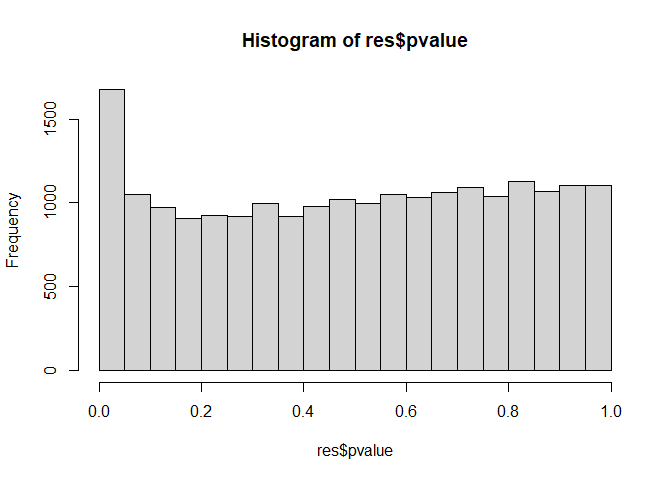

```r
hist(res$pvalue)
```

```r
# Set a more strict FDR cutoff
sum(res05$padj < 0.05, na.rm = TRUE)
```

```
## [1] 188
```

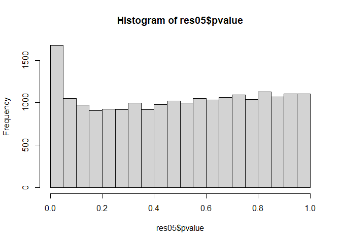

```r
hist(res05$pvalue)
```

## FDR estimations

```r
qobj <- qvalue(res$pvalue)

summary(qobj)
```

```
##
## Call:
## qvalue(p = res$pvalue)
##
## pi0: 1
##
## Cumulative number of significant calls:
##
##           <1e-04 <0.001 <0.01 <0.025 <0.05 <0.1    <1
## p-value       97    240   698   1103  1673 2724 21030
## q-value        9     18    74    113   169  258 21030
## local FDR      8     10    38     67    89  143  2155
```

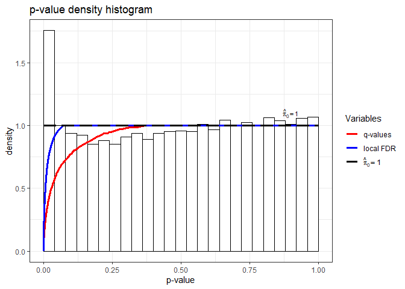

```r
hist(qobj)
```

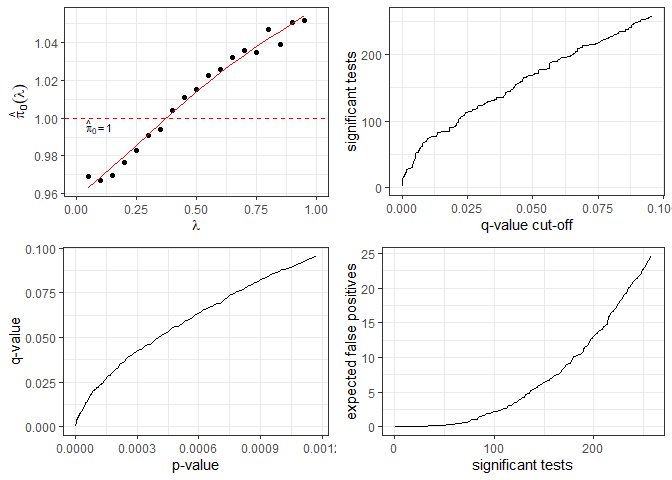

```r
plot(qobj)
```

## Test interaction term

```r
# dds2 <- DESeqDataSetFromMatrix(
#   countData = geneCounts,
#   colData = metadata,
#   design = ~ cell_type + patient_group + cell_type:patient_group
# )
#
# dds2 <- estimateSizeFactors(dds2)
#
# keep <- rowSums(counts(dds2)) >= 10
#
# dds2 <- dds2[keep, ]
#
# dds2$patient_group <- relevel(dds2$patient_group, ref = "non_smoker")
#
# dds2 <- DESeq(dds2)
#
# resultsNames(dds2)
#
# res105 <- results(dds2, alpha = 0.1)
#
# summary(res105)
#
# sum(res105$padj < 0.1, na.rm = TRUE)
#
# hist(res105$pvalue)
#
# qobj2 <- qvalue(res105$pvalue)
#
# summary(qobj2)
#
# hist(qobj2)
#
# plot(qobj2)
```

## Viewing DEG’s alternate contracts

```r
# Next im curious about seeing the remaining group comparisons

# COPD vs Non-Smoker
resCOPD <- results(dds, alpha = 0.05, contrast = c("patient_group", "copd", "non_smoker"))

head(as.data.frame(resCOPD))
```

|  | baseMean | log2FoldChange | lfcSE | stat | pvalue | padj |
| --- | --- | --- | --- | --- | --- | --- |
| WASH7P | 57.3696466 | 0.08037819 | 0.1867877 | 0.4303185 | 0.6669640 | 0.8284901 |
| RP11-34P13.7 | 0.9900037 | -0.23382369 | 1.0812093 | -0.2162613 | 0.8287841 | NA |
| AL627309.1 | 239.9914900 | 0.18842882 | 0.2227410 | 0.8459549 | 0.3975779 | 0.6272635 |
| RP11-34P13.13 | 51.9955887 | 0.05367629 | 0.3225291 | 0.1664231 | 0.8678240 | 0.9391502 |
| AP006222.2 | 10.9806154 | 0.63915379 | 0.4802686 | 1.3308257 | 0.1832464 | 0.4104837 |
| MTND1P23 | 5.9585223 | 0.13930616 | 0.3649741 | 0.3816878 | 0.7026929 | 0.8511484 |

```r
summary(resCOPD)
```

```
##
## out of 21090 with nonzero total read count
## adjusted p-value < 0.05
## LFC > 0 (up)       : 779, 3.7%
## LFC < 0 (down)     : 704, 3.3%
## outliers [1]       : 60, 0.28%
## low counts [2]     : 5699, 27%
## (mean count < 3)
## [1] see 'cooksCutoff' argument of ?results
## [2] see 'independentFiltering' argument of ?results
```

```r
sum(resCOPD$padj < 0.05, na.rm = TRUE)
```

```
## [1] 1483
```

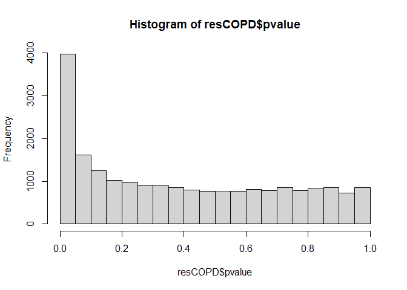

```r
hist(resCOPD$pvalue)
```

```r
qobj <- qvalue(resCOPD$pvalue)

summary(qobj)
```

```
##
## Call:
## qvalue(p = resCOPD$pvalue)
##
## pi0: 0.7801735
##
## Cumulative number of significant calls:
##
##           <1e-04 <0.001 <0.01 <0.025 <0.05 <0.1    <1
## p-value      327    791  2011   2934  3970 5580 21021
## q-value       60    154   463    926  1473 2317 21030
## local FDR     39     96   273    476   799 1257 11013
```

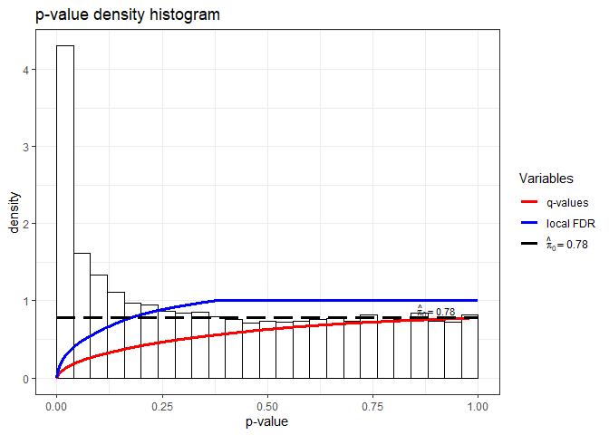

```r
hist(qobj)
```

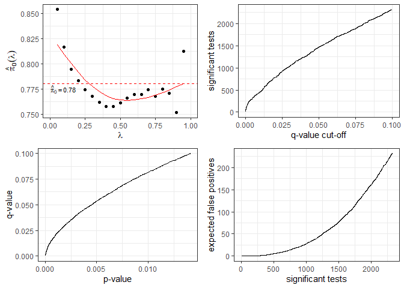

```r
plot(qobj)
```

```r
# COPD vs Smoker
resWild <- results(dds, alpha = 0.05, contrast = c("patient_group", "copd", "smoker"))

head(as.data.frame(resWild))
```

|  | baseMean | log2FoldChange | lfcSE | stat | pvalue | padj |
| --- | --- | --- | --- | --- | --- | --- |
| WASH7P | 57.3696466 | -0.2417125 | 0.1838088 | -1.3150211 | 0.188502798 | 0.4203488 |
| RP11-34P13.7 | 0.9900037 | -1.1400459 | 1.0391671 | -1.0970766 | 0.272607930 | NA |
| AL627309.1 | 239.9914900 | -0.2320556 | 0.2212294 | -1.0489368 | 0.294207204 | 0.5322674 |
| RP11-34P13.13 | 51.9955887 | -0.7402395 | 0.3142145 | -2.3558416 | 0.018480796 | 0.1233052 |
| AP006222.2 | 10.9806154 | 1.8655482 | 0.5105159 | 3.6542409 | 0.000257944 | NA |
| MTND1P23 | 5.9585223 | -0.1210034 | 0.3525516 | -0.3432217 | 0.731431678 | NA |

```r
summary(resWild)
```

```
##
## out of 21090 with nonzero total read count
## adjusted p-value < 0.05
## LFC > 0 (up)       : 434, 2.1%
## LFC < 0 (down)     : 357, 1.7%
## outliers [1]       : 60, 0.28%
## low counts [2]     : 8145, 39%
## (mean count < 13)
## [1] see 'cooksCutoff' argument of ?results
## [2] see 'independentFiltering' argument of ?results
```

```r
sum(resWild$padj < 0.05, na.rm = TRUE)
```

```
## [1] 791
```

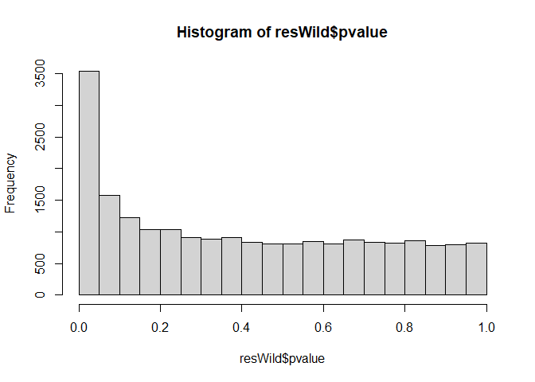

```r
hist(resWild$pvalue)
```

```r
qobj <- qvalue(resWild$pvalue)

summary(qobj)
```

```
##
## Call:
## qvalue(p = resWild$pvalue)
##
## pi0: 0.7705233
##
## Cumulative number of significant calls:
##
##           <1e-04 <0.001 <0.01 <0.025 <0.05 <0.1    <1
## p-value      167    472  1578   2493  3536 5112 21023
## q-value       21     36   174    327   708 1539 21030
## local FDR     13     25    88    187   356  785 19802
```

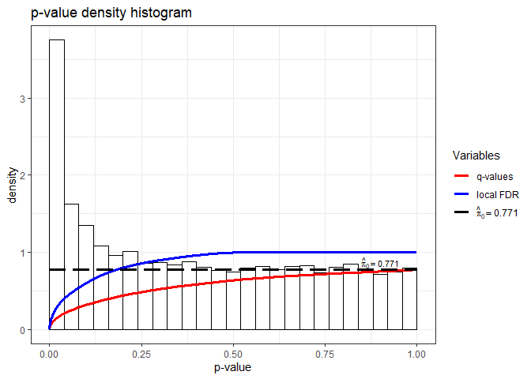

```r
hist(qobj)
```

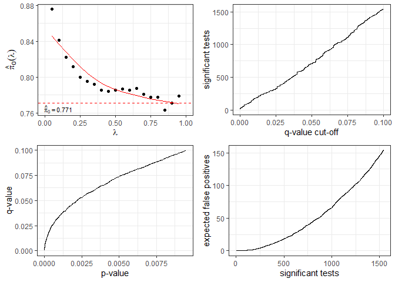

```r
plot(qobj)
```

## Log fold Skrink DEG’s

Aids in visualization and gene ranking

```r
# Adaptive t prior shrinkage estimator
resLFC <- lfcShrink(dds,
  coef = "patient_group_smoker_vs_non_smoker",
  type = "apeglm"
)
```

```
## using 'apeglm' for LFC shrinkage. If used in published research, please cite:
##     Zhu, A., Ibrahim, J.G., Love, M.I. (2018) Heavy-tailed prior distributions for
##     sequence count data: removing the noise and preserving large differences.
##     Bioinformatics. https://doi.org/10.1093/bioinformatics/bty895
```

```r
# Original DESeq2 shrinkage estimator, an adaptive Normal distribution as prior.
resNorm <- lfcShrink(dds,
  coef = "patient_group_smoker_vs_non_smoker",
  type = "normal"
)
```

```
## using 'normal' for LFC shrinkage, the Normal prior from Love et al (2014).
##
## Note that type='apeglm' and type='ashr' have shown to have less bias than type='normal'.
## See ?lfcShrink for more details on shrinkage type, and the DESeq2 vignette.
## Reference: https://doi.org/10.1093/bioinformatics/bty895
```

```r
# Adaptive shrinkage estimator. Fits a mixture of Normal distributions to form the prior
resAsh <- lfcShrink(dds,
  coef = "patient_group_smoker_vs_non_smoker",
  type = "ashr"
)
```

```
## using 'ashr' for LFC shrinkage. If used in published research, please cite:
##     Stephens, M. (2016) False discovery rates: a new deal. Biostatistics, 18:2.
##     https://doi.org/10.1093/biostatistics/kxw041
```

## Subset results

```r
# Extract differentially expressed genes
subRes05 <- subset(res, padj < 0.05)

subRes01 <- subset(res, padj < 0.01)

subRes005 <- subset(res, padj < 0.005)

# DEG05 <- subRes05@rownames
#
# DEG01 <- subRes01@rownames
#
# DEG005 <- subRes005@rownames
```

### Plot subset results

```r
# counts |>
#   filter(genes %in% DEG) |>
#   ggplot(aes(x = samples, y = genes, fill = counts)) +
#   geom_tile() +
#   scale_fill_gradient(low = "white", high = "red") +
#   theme(axis.text.x = element_text(angle = 45, hjust = 1))
```

# Visualize

## Visualize DEG results

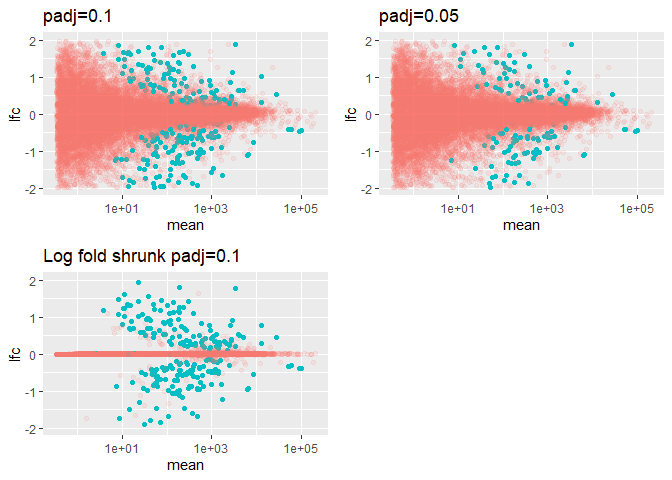

```r
# Visualize log2 fold changes of a given variable over the mean of normalized counts for all samples

res_list <- list(
  "padj=0.1" = res,
  "padj=0.05" = res05,
  "Log fold shrunk padj=0.1" = resLFC
)

plotMA_arrange_iterative(res_list)
```

## Visualizing alternate contrasts

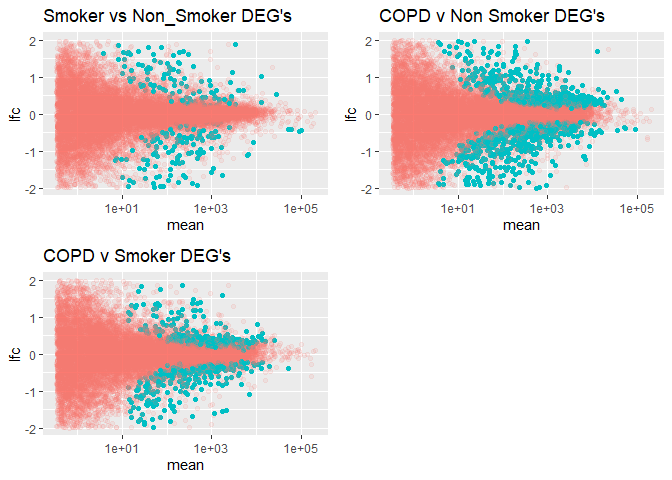

```r
res_list <- list(
  "Smoker vs Non_Smoker DEG's" = res,
  "COPD v Non Smoker DEG's" = resCOPD,
  "COPD v Smoker DEG's" = resWild
)

plotMA_arrange_iterative(res_list)
```

## Visualize Log Fold Shrunken MA Plots

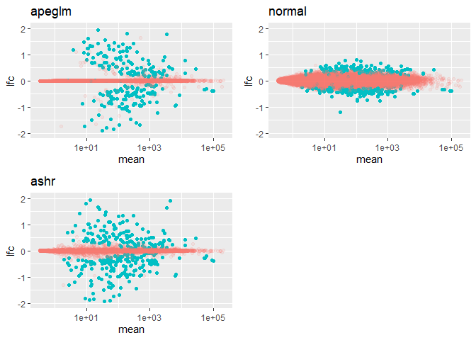

```r
# Plot log fold shrunken DEG's
res_list <- list(
  "apeglm" = resLFC,
  "normal" = resNorm,
  "ashr" = resAsh
)

plotMA_arrange_iterative(res_list)
```

## visualize subset results

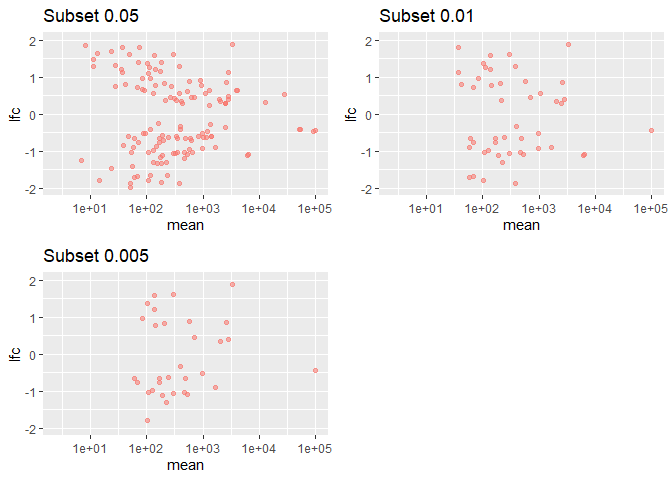

```r
# Plot log fold shrunken DEG's
res_list <- list(
  "Subset 0.05" = subRes05,
  "Subset 0.01" = subRes01,
  "Subset 0.005" = subRes005
)

plotMA_arrange_iterative(res_list)
```

**Note**: If there is unwanted variation present in the data (e.g. batch effects) it is always recommend to correct for this, which can be accommodated in DESeq2 by including in the design any known batch variables or by using functions/packages such as svaseq in sva (Leek 2014) or the RUV functions in RUVSeq (Risso et al. 2014) to estimate variables that capture the unwanted variation. In addition, the ashr developers have a specific method for accounting for unwanted variation in combination with ashr (Gerard and Stephens 2017).

# Transform

## Raw gene variance

Raw RNA sequencing counts have a high degree of variability; which increases with a genes average expression level. This variability needs to be accounted before some downstream analysis such as visualization and clustering. We do this by transforming the data such that the variance is stabilized across the entire spectrum of expression values, allowing for use of statistical models/methods where that is a requirement.

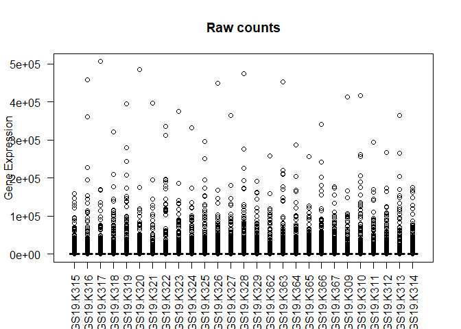

```r
# Filter out low expressed genes
keep <- rowSums(geneCounts) > 10

filtCounts <- as.matrix(geneCounts[keep, ])

# Visualize gene expression values by sample
boxplot(filtCounts, main = "Raw counts", ylab = "Gene Expression", las = 2)
```

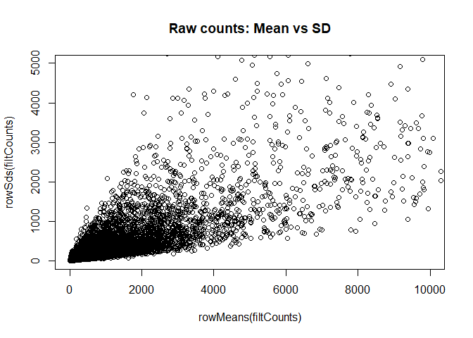

```r
# Mean expression vs standard deviation (SD)
plot(rowMeans(filtCounts), rowSds(filtCounts),
  main = "Raw counts: Mean vs SD",
  xlim = c(0, 10000),
  ylim = c(0, 5000)
)
```

```r
# Save as ggplot
Raw <- ggplot(filtCounts, aes(
  x = rowMeans(filtCounts),
  y = rowSds(filtCounts)
)) +
  geom_point() +
  geom_smooth() +
  labs(title = "Raw", x = "Mean", y = "SD")
```

## Various Transformations

Log2 fold transformation were the standard in the past, but they can result in over representation of low expressed genes. As such various other methods are implemented. The goal is that the standard deviation stays consistent across all mean values of gene expression. vst and rlog have pros and cons determined by the number of samples.

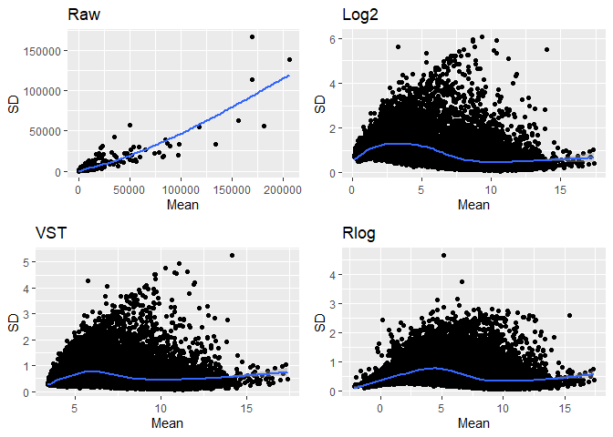

```r
# Get log2 counts
logcounts <- log2(filtCounts + 1)

# Plot mean vs SD
Log2 <- ggplot(logcounts, aes(
  x = rowMeans(logcounts),
  y = rowSds(logcounts)
)) +
  geom_point() +
  geom_smooth() +
  labs(title = "Log2", x = "Mean", y = "SD")

# Variance stabilizing transformation
vst_counts <- vst(filtCounts)

# Plot
VST <- ggplot(vst_counts, aes(
  x = rowMeans(vst_counts),
  y = rowSds(vst_counts)
)) +
  geom_point() +
  geom_smooth() +
  labs(title = "VST", x = "Mean", y = "SD")

# Rlog counts
rlog_counts <- rlog(filtCounts)

# Plot
Rlog <- ggplot(rlog_counts, aes(
  x = rowMeans(rlog_counts),
  y = rowSds(rlog_counts)
)) +
  geom_point() +
  geom_smooth() +
  labs(title = "Rlog", x = "Mean", y = "SD")

# Arrange Plots
grid.arrange(Raw, Log2, VST, Rlog, nrow = 2)
```

```r
# select <- order(rowMeans(rlog_counts), decreasing = TRUE)[1:20]
#
# df <- as.data.frame(metadata[, c("patient_group", "cell_type")])
#
# pheatmap(rlog_counts[select,], main = "rlog",
#          cluster_rows = TRUE, show_rownames = TRUE,
#          cluster_cols = TRUE, show_colnames = FALSE)
```

```r
# Variance stabilizing transformation. (log2 scaling for large counts)
vsd <- vst(dds, blind = FALSE)

rld <- rlog(dds, blind = FALSE)

ntd <- normTransform(dds)


#
# meanSdPlot(assay(ntd))
#
# meanSdPlot(assay(vsd))
#
# meanSdPlot(assay(rld))
```

# Quality Assesment

## Quality assesment with Heatmaps

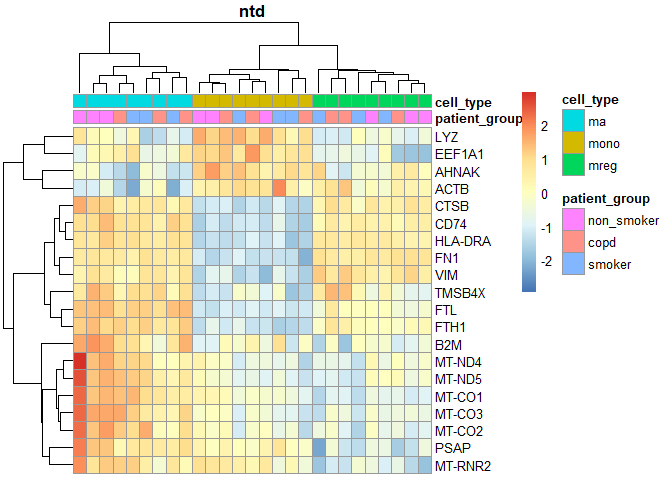

```r
select <- order(rowMeans(counts(dds, normalized = TRUE)),
  decreasing = TRUE
)[1:20]

df <- as.data.frame(colData(dds)[, c("patient_group", "cell_type")])

pheatmap(assay(ntd)[select, ],
  cluster_rows = TRUE, show_rownames = TRUE,
  cluster_cols = TRUE, annotation_col = df, show_colnames = FALSE,
  main = "ntd", scale = "row"
)
```

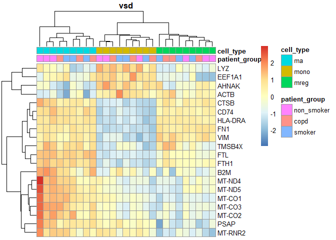

```r
pheatmap(assay(vsd)[select, ],
  cluster_rows = TRUE, show_rownames = TRUE,
  cluster_cols = TRUE, annotation_col = df, show_colnames = FALSE,
  main = "vsd", scale = "row"
)
```

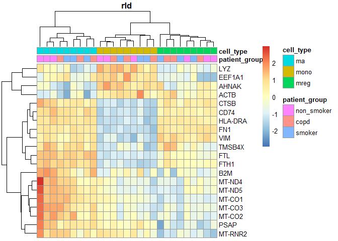

```r
pheatmap(assay(rld)[select, ],
  cluster_rows = TRUE, show_rownames = TRUE,
  cluster_cols = TRUE, annotation_col = df, show_colnames = FALSE,
  main = "rld", scale = "row"
)
```

## Sample distance

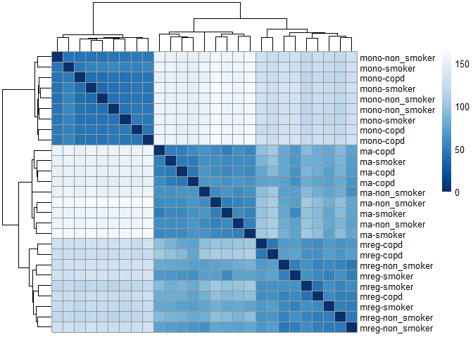

```r
# Determine between group variety
sampleDists <- dist(t(assay(vsd)))

sampleDistMatrix <- as.matrix(sampleDists)

rownames(sampleDistMatrix) <- paste(vsd$cell_type, vsd$patient_group, sep = "-")

colnames(sampleDistMatrix) <- NULL

colors <- colorRampPalette(rev(brewer.pal(9, "Blues")))(255)

pheatmap(sampleDistMatrix,
  clustering_distance_rows = sampleDists,
  clustering_distance_cols = sampleDists,
  col = colors
)
```

## PCA plots

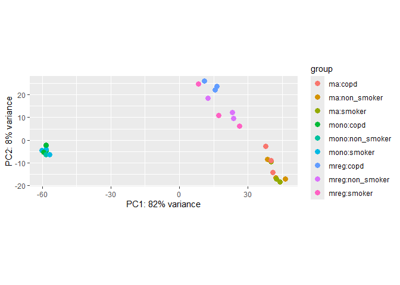

```r
plotPCA(vsd, intgroup = c("cell_type", "patient_group"))
```

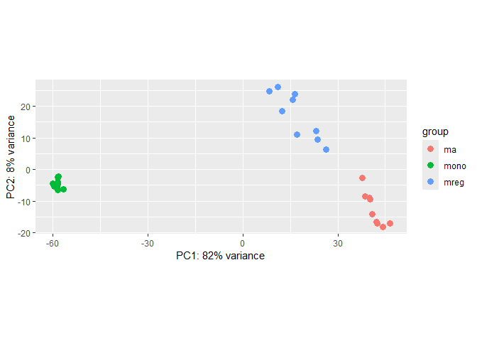

```r
plotPCA(vsd, intgroup = c("cell_type"))
```

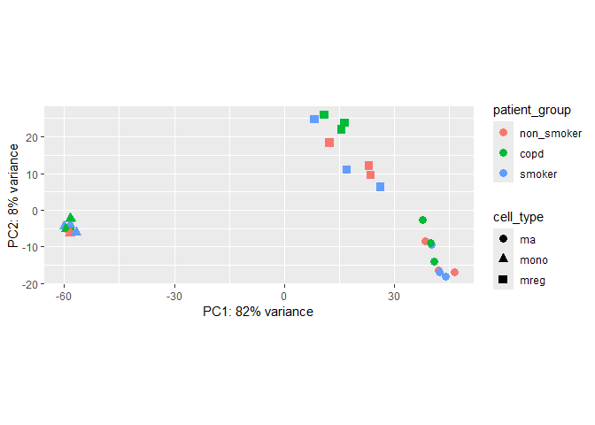

```r
pcaData <- plotPCA(vsd,
  intgroup = c("cell_type", "patient_group"),
  returnData = TRUE
)

percentVar <- round(100 * attr(pcaData, "percentVar"))

ggplot(pcaData, aes(PC1, PC2, color = patient_group, shape = cell_type)) +
  geom_point(size = 3) +
  xlab(paste0("PC1: ", percentVar[1], "% variance")) +
  ylab(paste0("PC2: ", percentVar[2], "% variance")) +
  coord_fixed()
```

## Plot Counts

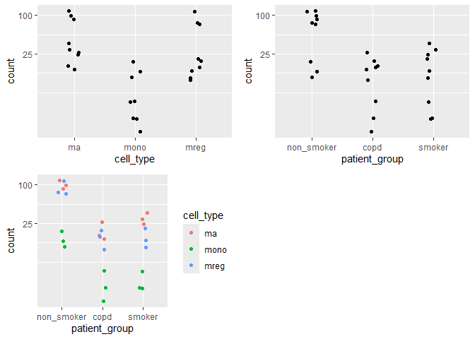

```r
# Plot the gene with the smallest p adj value across specified groupings
c1 <- plotCounts(dds, gene = which.min(res$padj), intgroup = c("cell_type"), returnData = TRUE)

c1_plot <- ggplot(c1, aes(x = cell_type, y = count)) +
  geom_point(position = position_jitter(w = 0.1, h = 0)) +
  scale_y_log10(breaks = c(25, 100, 400))

c2 <- plotCounts(dds, gene = which.min(res$padj), intgroup = c("patient_group"), returnData = TRUE)

c2_plot <- ggplot(c2, aes(x = patient_group, y = count)) +
  geom_point(position = position_jitter(w = 0.1, h = 0)) +
  scale_y_log10(breaks = c(25, 100, 400))

c3 <- plotCounts(dds, gene = which.min(res$padj), intgroup = c("cell_type", "patient_group"), returnData = TRUE)

c3_plot <- ggplot(c3, aes(x = patient_group, y = count, color = cell_type)) +
  geom_point(position = position_jitter(w = 0.1, h = 0)) +
  scale_y_log10(breaks = c(25, 100, 400))

gridExtra::grid.arrange(c1_plot, c2_plot, c3_plot, nrow = 2)
```

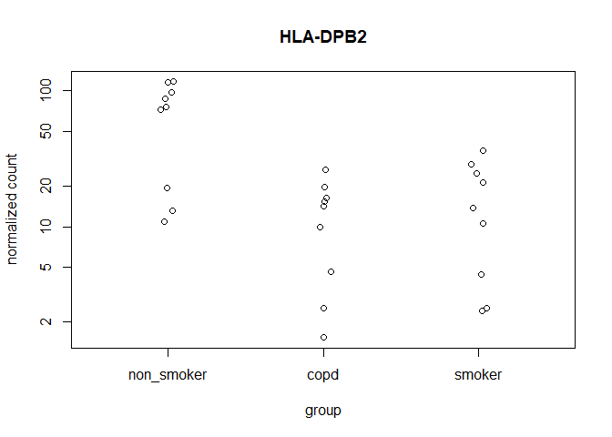

```r
# plot chosen genes per chosen conditions
plotCounts(dds, gene = which.min(res$padj), intgroup = "patient_group")
```

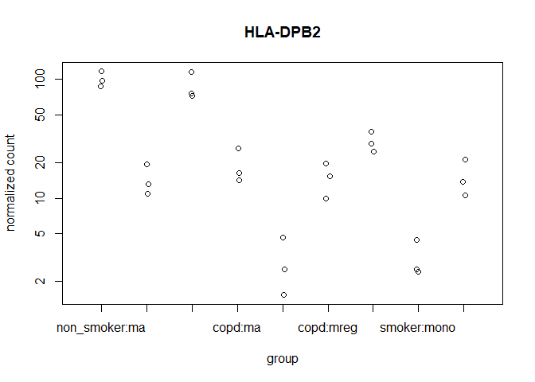

```r
plotCounts(dds, gene = which.min(res$padj), intgroup = c("patient_group", "cell_type"))
```

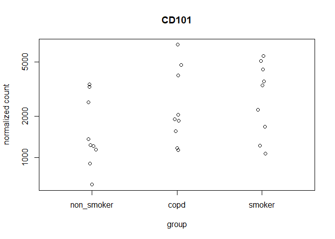

```r
plotCounts(dds, gene = "CD101", intgroup = "patient_group")
```

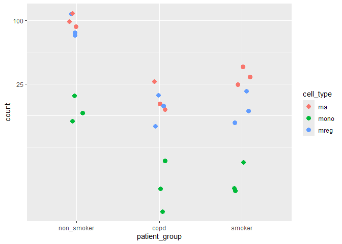

```r
p <- plotCounts(dds,
  gene = which.min(res$padj),
  intgroup = c("patient_group", "cell_type"),
  returnData = TRUE
)

ggplot(p, aes(x = patient_group, y = count, color = cell_type)) +
  geom_point(position = position_jitter(w = 0.1, h = 0), size = 3) +
  scale_y_log10(breaks = c(25, 100, 400))
```